# Homework 4

Part 2: Using a decision tree.

5. Which variable do you expect to be at the root of the decision tree? Explain your answer and use a graph to support your answer.

ANSWER: Root Node represents the entire population or sample and further gets divided into two or more sets. In this case, the variable radius_mean represents the entire population and can easily divide into 2 major groups representing benign and malignant cancer

```r
library("party")
Cancer.fit<-ctree(formula = diagnosis ~ radius_mean + texture_mean + smoothness_mean + compactness_mean,
                  data=cancer_df)
```

```r
results = predict(Cancer.fit)
table(cancer_df$diagnosis, results)
```

```
##    results
##       B   M
##   B 338  19
##   M  15 197
```

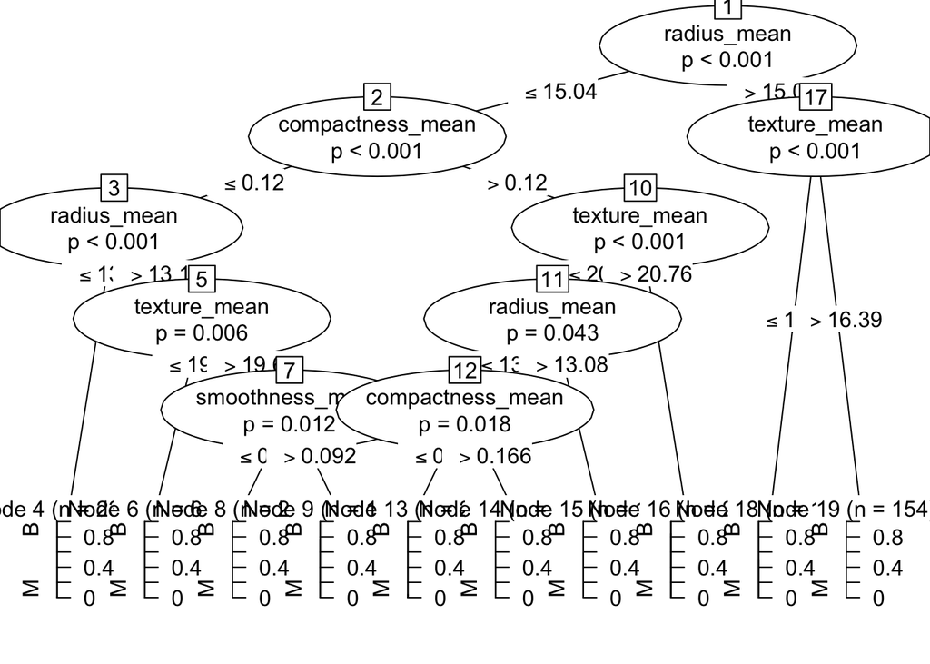

```r
plot(Cancer.fit)
```

```r
library(AUC)
```

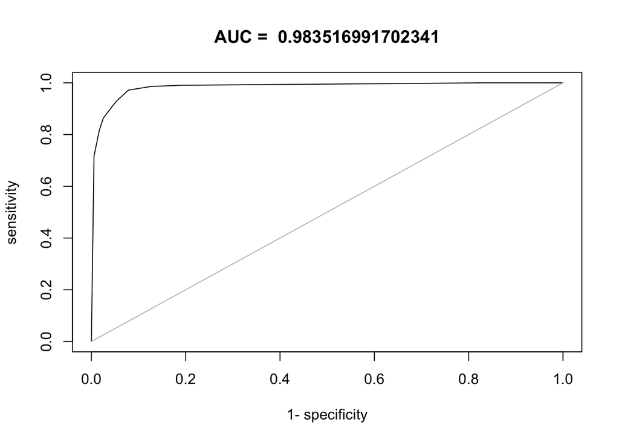

```r
resultsr = predict(Cancer.fit, type="response")
resultsp = predict(Cancer.fit, type="prob")
resultsp.df = t(as.data.frame(resultsp))

roc_result = roc(resultsp.df[,2],cancer_df$diagnosis)
plot(roc_result, main=paste("AUC = ", auc(roc_result), sep=" "))
```

```r
# An excellent model has AUC near to the 1 which means it has good measure of separability. The AUC value of 0.98 means that there is 98% chance that model will be able to distinguish between positive class and negative class.
```

6. Using the same training_set and test_set perform a decision tree using the “Party” package.

```r
library("party")
```

```r
Cancer.fit_TrainSet<-ctree(formula = diagnosis ~ radius_mean + texture_mean + smoothness_mean + compactness_mean,
                  data=split.train)
```

```r
results_TrainSet = predict(Cancer.fit_TrainSet)
table(split.train$diagnosis, results_TrainSet)
```

```
##    results_TrainSet
##       B   M
##   B 152  18
##   M  12 157
```

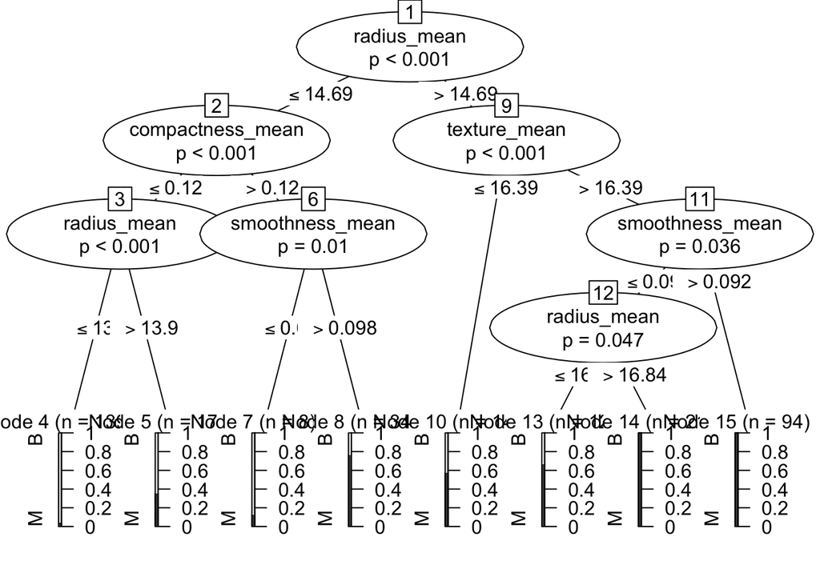

```r
plot(Cancer.fit_TrainSet)
```

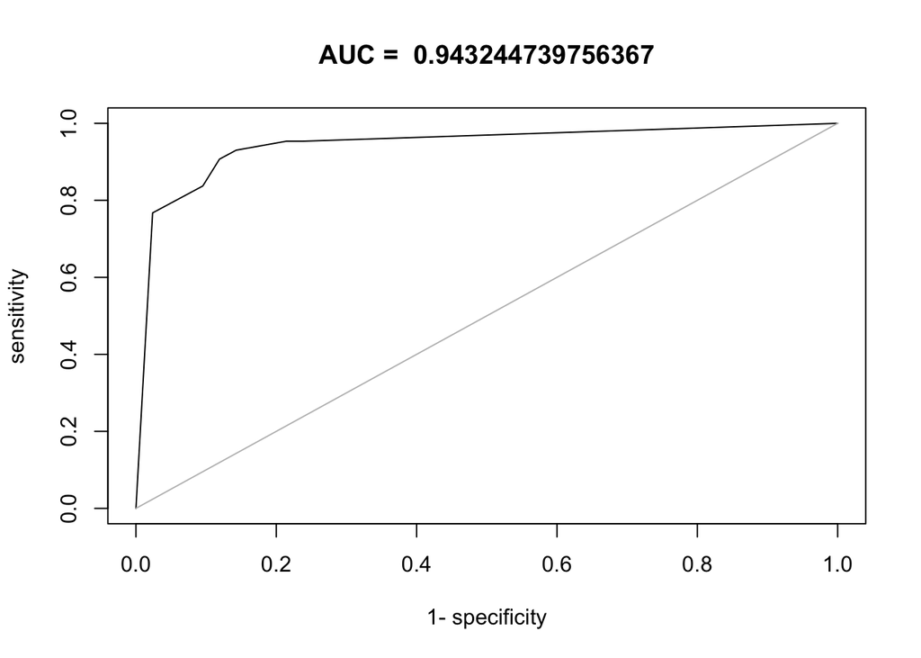

```r
library(AUC)
results1r = predict(Cancer.fit_TrainSet,newdata = split.test, type="response")
results1p = predict(Cancer.fit_TrainSet,newdata = split.test, type="prob")
results1p.df = t(as.data.frame(results1p))

roc_result1 = roc(results1p.df[,2],split.test$diagnosis)
plot(roc_result1, main=paste("AUC = ", auc(roc_result1), sep=" "))
```

7. Change the max_depth parameter and calculate your accuracy, precision, and recall for each depth. At which point do you think you have the least amount of over-fitting?

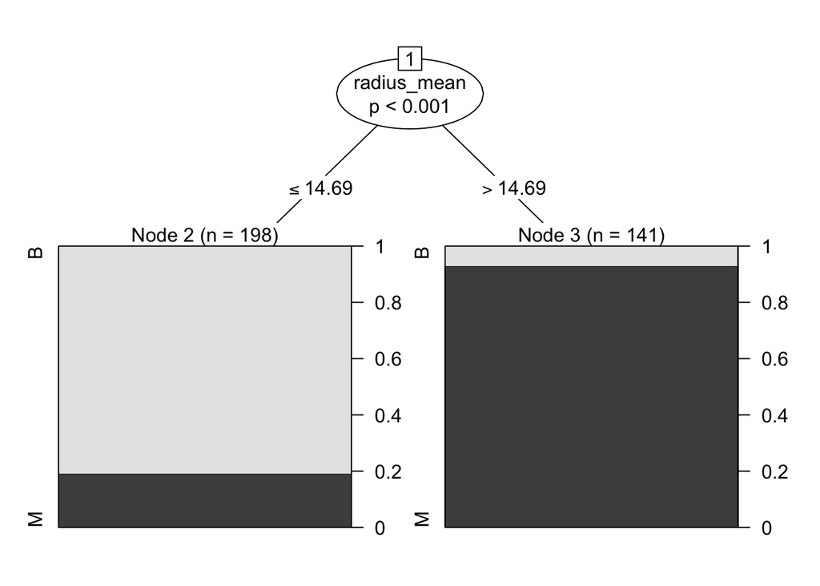

```r
#Changing the max depth to 1
Cancer.fit2<-ctree(formula = diagnosis ~ radius_mean + texture_mean + smoothness_mean + compactness_mean,
                   data = split.train,
                   controls = ctree_control(maxdepth = 1))
plot(Cancer.fit2)
```

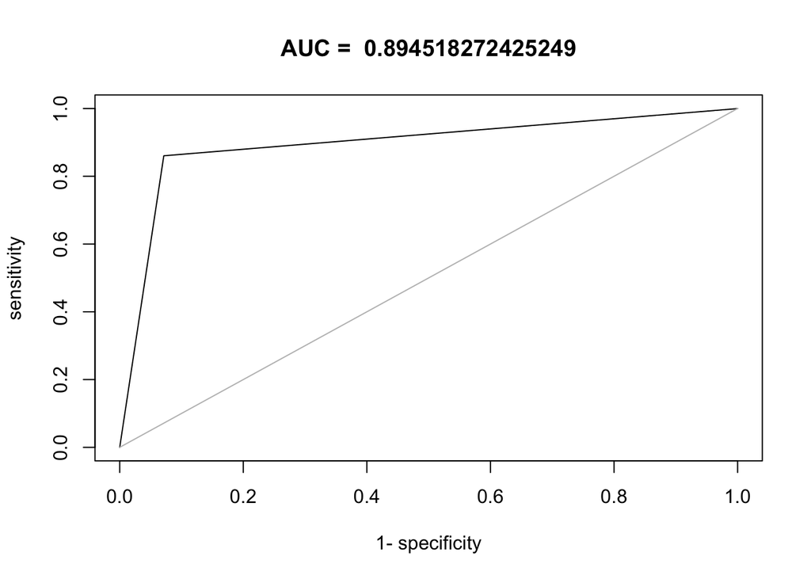

```r
Cancer.fit2_compare<-ctree(formula=diagnosis ~ radius_mean+texture_mean+smoothness_mean+compactness_mean, data=cancer_df,controls = ctree_control(maxdepth = 1))

results2r= predict(Cancer.fit2,newdata=split.test,type="response")
results2p = predict(Cancer.fit2, newdata=split.test,type="prob")
results2p.df = t(as.data.frame(results2p))
roc_result2 = roc(results2p.df[,2],split.test$diagnosis)
plot(roc_result2, main=paste("AUC = ", auc(roc_result2), sep=" "))
```

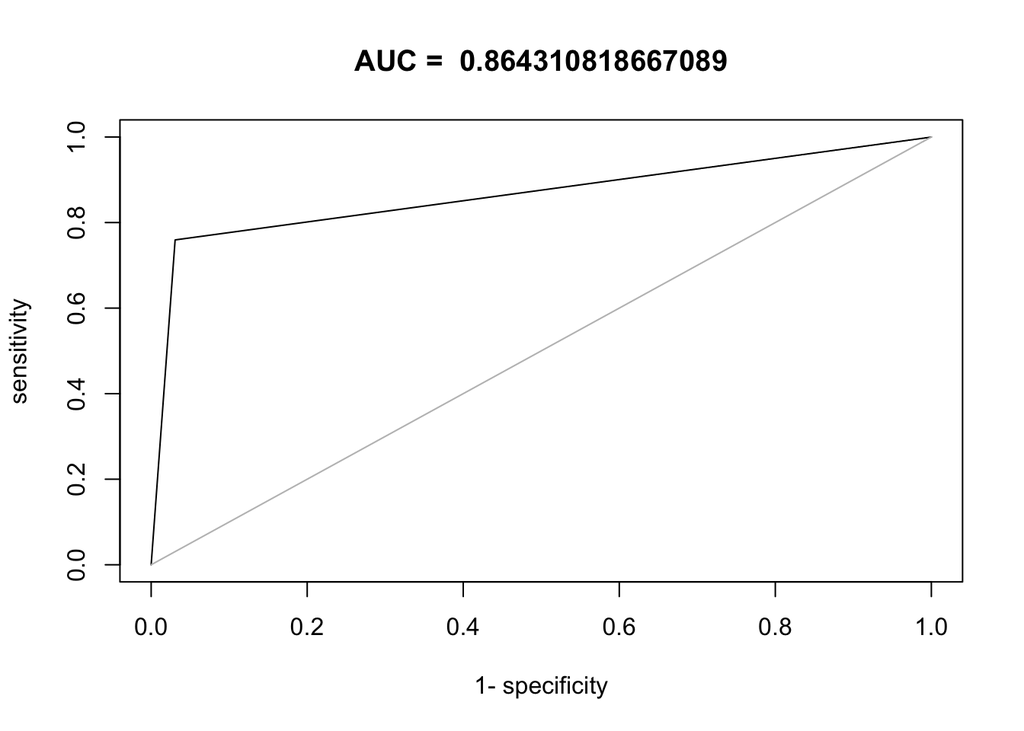

```r
results2r= predict(Cancer.fit2_compare,newdata=cancer_df,type="response")
results2p = predict(Cancer.fit2_compare,newdata=cancer_df,type="prob")
results2p.df = t(as.data.frame(results2p))
roc_result2 = roc(results2p.df[,2],cancer_df$diagnosis)
plot(roc_result2, main=paste("AUC = ", auc(roc_result2), sep=" "))
```

```r
pr.split.Cancer.fit2<-predict(Cancer.fit2, newdata=split.test, type="response")
pr.perf.Cancer.fit2 = pr.split.Cancer.fit2
pr.perf.Cancer.fit2[pr.split.Cancer.fit2>0.5] = "M"
pr.perf.Cancer.fit2[pr.split.Cancer.fit2<=0.5]= "B"
confmat.Cancer.fit2 <- table(split.test[,"diagnosis"], pr.perf.Cancer.fit2, dnn=c("actual", "predicted"))
confmat.Cancer.fit2
```

```
##       predicted
## actual  B  M
##      B 39  3
##      M  6 37
```

```r
# Calculating accuracy for max depth = 1
TP.Cancer.fit2=confmat.Cancer.fit2["M","M"]
TN.Cancer.fit2=confmat.Cancer.fit2["B","B"]
FP.Cancer.fit2=confmat.Cancer.fit2["B","M"]
FN.Cancer.fit2=confmat.Cancer.fit2["M","B"]

accuracy.Cancer.fit2 = (TP.Cancer.fit2+TN.Cancer.fit2)/(TP.Cancer.fit2+TN.Cancer.fit2+FP.Cancer.fit2+FN.Cancer.fit2)
accuracy.Cancer.fit2
```

```
## [1] 0.8941176
```

```r
# Calculating precision for max depth = 1
precision.Cancer.fit2 = TP.Cancer.fit2/(TP.Cancer.fit2+FP.Cancer.fit2)
precision.Cancer.fit2
```

```
## [1] 0.925
```

```r
# Calculating recall for max depth = 1
recall.Cancer.fit2 = TP.Cancer.fit2/(TP.Cancer.fit2+FN.Cancer.fit2)
recall.Cancer.fit2
```

```
## [1] 0.8604651
```

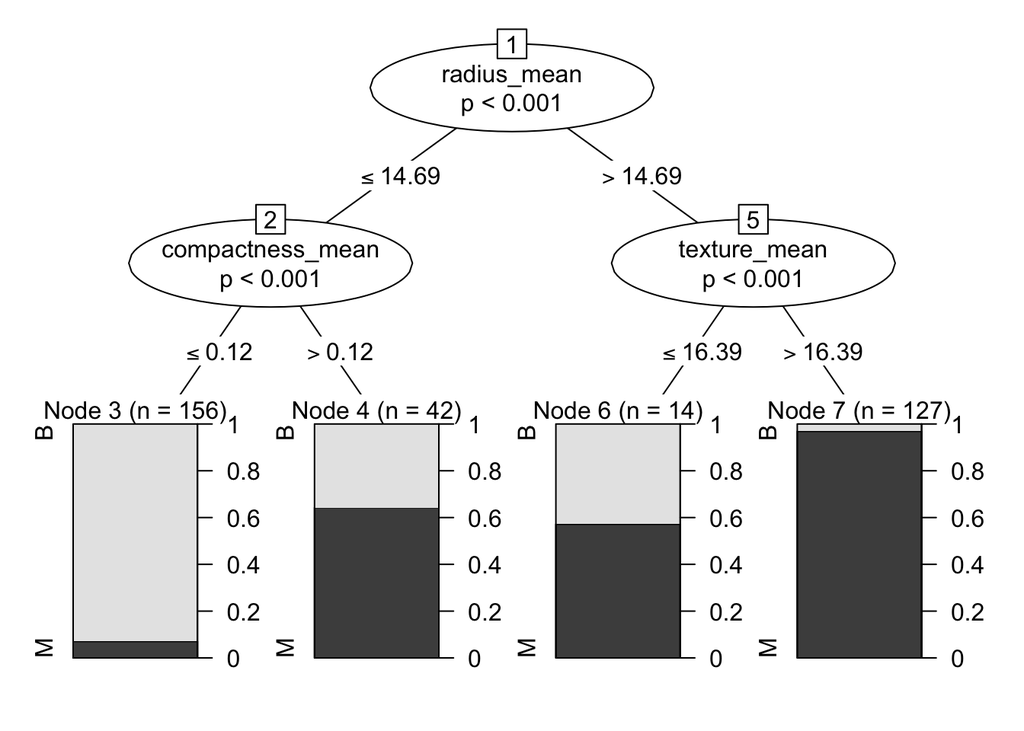

```r
#Changing the max depth to 2
Cancer.fit3<-ctree(formula = diagnosis ~ radius_mean + texture_mean + smoothness_mean + compactness_mean,
                   data=split.train,
                   controls = ctree_control(maxdepth = 2))
plot(Cancer.fit3)
```

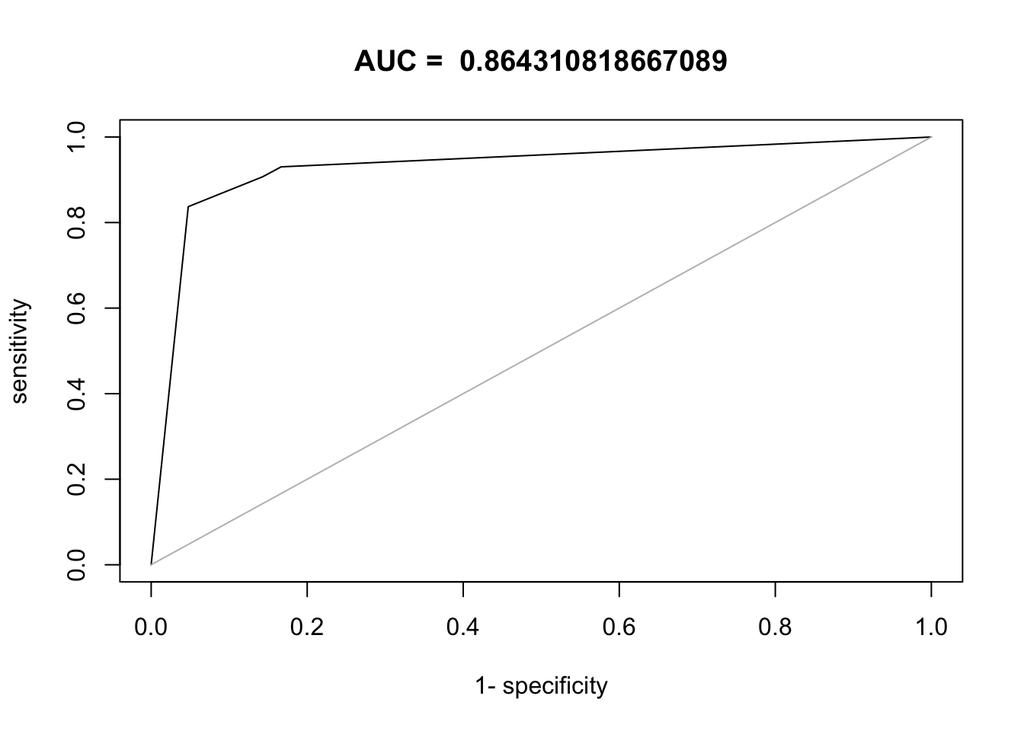

```r
Cancer.fit3_compare<-ctree(formula=diagnosis ~ radius_mean+texture_mean+smoothness_mean+compactness_mean, data=cancer_df,controls = ctree_control(maxdepth = 2))

results3r= predict(Cancer.fit3,newdata=split.test,type="response")
results3p = predict(Cancer.fit3, newdata=split.test,type="prob")
results3p.df = t(as.data.frame(results3p))
roc_result3 = roc(results3p.df[,2],split.test$diagnosis)
plot(roc_result3, main=paste("AUC = ", auc(roc_result2), sep=" "))
```

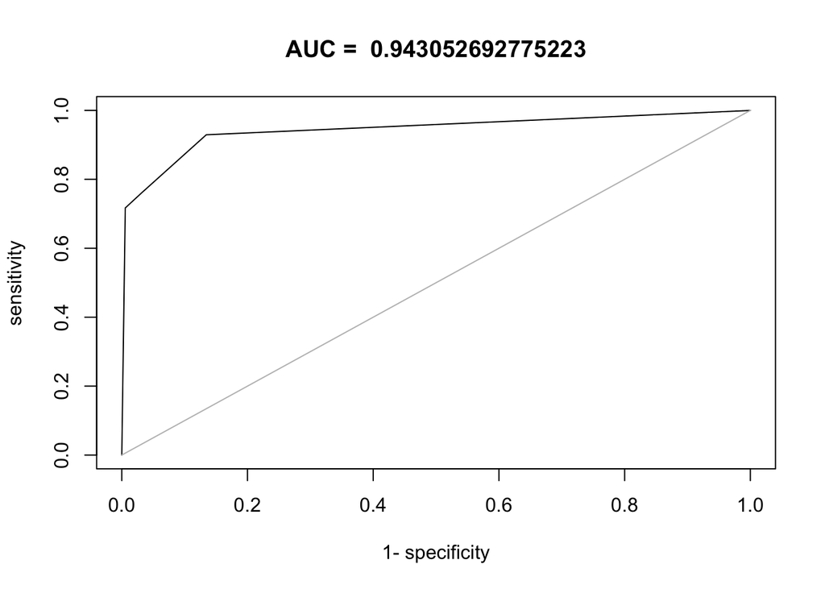

```r
results3r= predict(Cancer.fit3_compare,newdata=cancer_df,type="response")
results3p = predict(Cancer.fit3_compare,newdata=cancer_df,type="prob")
results3p.df = t(as.data.frame(results3p))
roc_result3 = roc(results3p.df[,2],cancer_df$diagnosis)
plot(roc_result3, main=paste("AUC = ", auc(roc_result3), sep=" "))
```

```r
pr.split.Cancer.fit3<-predict(Cancer.fit3, newdata=split.test, type="response")
pr.perf.Cancer.fit3 = pr.split.Cancer.fit3
pr.perf.Cancer.fit3[pr.split.Cancer.fit3>0.5] = "M"
pr.perf.Cancer.fit3[pr.split.Cancer.fit3<=0.5]= "B"
confmat.Cancer.fit3<-table(split.test[,"diagnosis"], pr.perf.Cancer.fit3, dnn=c("actual", "predicted"))
confmat.Cancer.fit3
```

```
##       predicted
## actual  B  M
##      B 35  7
##      M  3 40
```

```r
# Calculating accuracy for max depth = 2
TP.Cancer.fit3=confmat.Cancer.fit3["M","M"]
TN.Cancer.fit3=confmat.Cancer.fit3["B","B"]
FP.Cancer.fit3=confmat.Cancer.fit3["B","M"]
FN.Cancer.fit3=confmat.Cancer.fit3["M","B"]

accuracy.Cancer.fit3 = (TP.Cancer.fit3+TN.Cancer.fit3)/(TP.Cancer.fit3+TN.Cancer.fit3+FP.Cancer.fit3+FN.Cancer.fit3)
accuracy.Cancer.fit3
```

```
## [1] 0.8823529
```

```r
# Calculating precision for max depth = 2
precision.Cancer.fit3 = TP.Cancer.fit3/(TP.Cancer.fit3+FP.Cancer.fit3)
precision.Cancer.fit3
```

```
## [1] 0.8510638
```

```r
# Calculating recall for max depth = 2
recall.Cancer.fit3 = TP.Cancer.fit3/(TP.Cancer.fit3+FN.Cancer.fit3)
recall.Cancer.fit3
```

```
## [1] 0.9302326
```

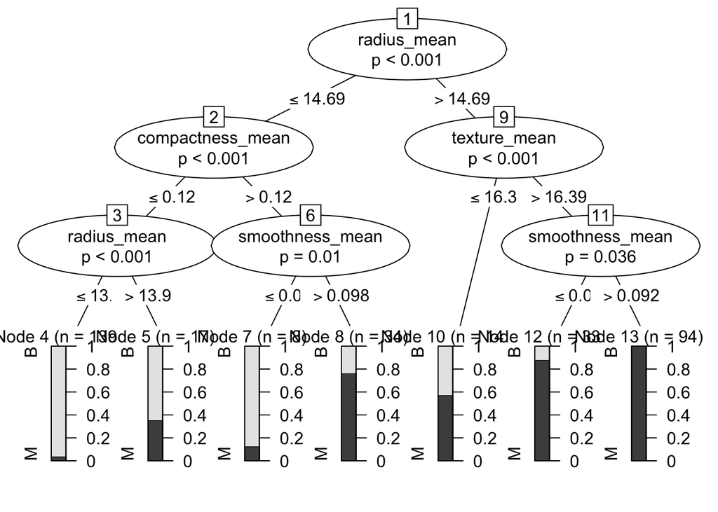

```r
#Changing the max depth to 3
Cancer.fit4<-ctree(formula = diagnosis ~ radius_mean + texture_mean + smoothness_mean + compactness_mean,
                   data = split.train,
                   controls = ctree_control(maxdepth = 3))
plot(Cancer.fit4)
```

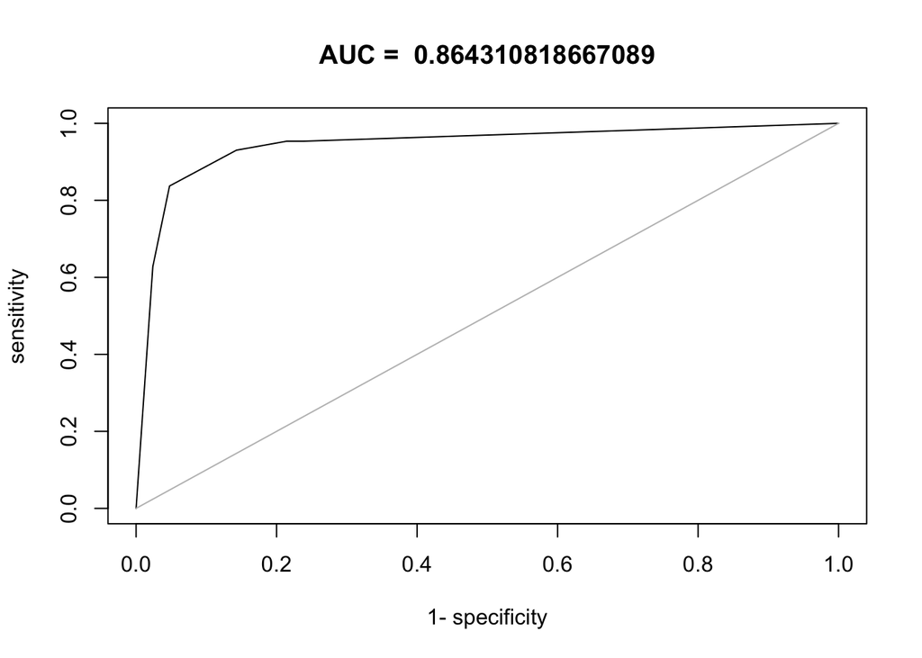

```r
Cancer.fit4_compare<-ctree(formula=diagnosis ~ radius_mean+texture_mean+smoothness_mean+compactness_mean, data=cancer_df,controls = ctree_control(maxdepth = 3))

results4r= predict(Cancer.fit4,newdata=split.test,type="response")
results4p = predict(Cancer.fit4,newdata=split.test,type="prob")
results4p.df = t(as.data.frame(results4p))
roc_result4 = roc(results4p.df[,2],split.test$diagnosis)
plot(roc_result4, main=paste("AUC = ", auc(roc_result2), sep=" "))
```

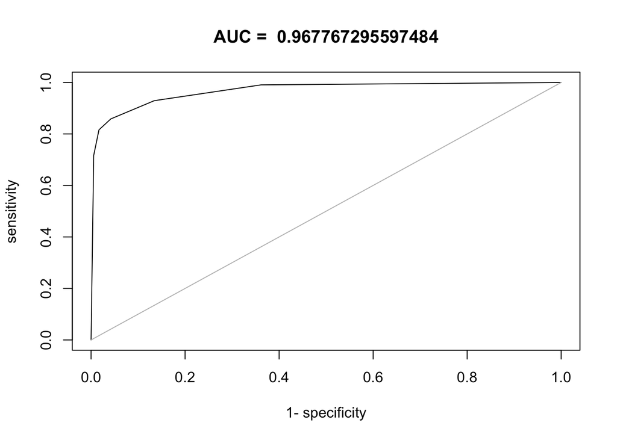

```r
results4r= predict(Cancer.fit4_compare,newdata=cancer_df,type="response")
results4p = predict(Cancer.fit4_compare,newdata=cancer_df,type="prob")
results4p.df = t(as.data.frame(results4p))
roc_result4 = roc(results4p.df[,2],cancer_df$diagnosis)
plot(roc_result4, main=paste("AUC = ", auc(roc_result4), sep=" "))
```

```r
pr.split.Cancer.fit4<-predict(Cancer.fit4, newdata=split.test, type="response")
pr.perf.Cancer.fit4 = pr.split.Cancer.fit4
pr.perf.Cancer.fit4[pr.split.Cancer.fit4>0.5] = "M"
pr.perf.Cancer.fit4[pr.split.Cancer.fit4<=0.5]= "B"
confmat.Cancer.fit4 <- table(split.test[,"diagnosis"], pr.perf.Cancer.fit4, dnn=c("actual", "predicted"))
confmat.Cancer.fit4
```

```
##       predicted
## actual  B  M
##      B 36  6
##      M  3 40
```

```r
# Calculating accuracy for max depth = 3
TP.Cancer.fit4=confmat.Cancer.fit4["M","M"]
TN.Cancer.fit4=confmat.Cancer.fit4["B","B"]
FP.Cancer.fit4=confmat.Cancer.fit4["B","M"]
FN.Cancer.fit4=confmat.Cancer.fit4["M","B"]

accuracy.Cancer.fit4 = (TP.Cancer.fit4+TN.Cancer.fit4)/(TP.Cancer.fit4+TN.Cancer.fit4+FP.Cancer.fit4+FN.Cancer.fit4)
accuracy.Cancer.fit4
```

```
## [1] 0.8941176
```

```r
# Calculating precision for max depth = 3
precision.Cancer.fit4 = TP.Cancer.fit4/(TP.Cancer.fit4+FP.Cancer.fit4)
precision.Cancer.fit4
```

```
## [1] 0.8695652
```